Análises March 06, 2018

# Levantamento das coletas sobre os tribunais

Os tribunais requisitados para esta apresentação foram os TRFs e TJs, entre eles,

1. TRF
   1. TRF-1
   2. TRF-2
   3. TRF-3
   4. TRF-5
2. TJ
   1. TJSP
   2. TJAL
   3. TJDFT
   4. TJRJ

Alguns deles não estão na análise, pois foram retirados para realizar uma coleta mais consistente, como por exemplo, o `TRF-2` ou tiveram problemas na coleta como `TJRJ`. Além disso, cabe destacar que o caso do `TRF-5` precisa ser discutido, pois a maioria das decisões não são capazes de informar o arquivamento ou não dos casos (irei explorar este caso ao longo do relatório).

```r
library(dplyr)
library(ggplot2)
library(stringr)
library(ggplot2)
```

## TRFs

### TRF-1

```r
trf1 <- readr::read_rds("/home/nathang/Documentos/Scripts and Documents/ESTAGIO_ABJ/ABJ/trfs/jurisprudencia/data-raw/rds_data/trf1.rds")
```

```r
glimpse(trf1)
```

```
## Observations: 322
## Variables: 16
## $ group                          <dbl> 1, 2, 3, 4, 5, 6, 7, 8, 9, 10, ...
## $ convocado                      <chr> NA, "JUIZ FEDERAL CARLOS D'AVIL...
## $ data_decisao                   <chr> "19/10/2016", "21/09/2016", "21...
## $ decisao                        <chr> "A Seção, rejeitou a denúncia e...
## $ orgao                          <chr> "SEGUNDA SEÇÃO", "SEGUNDA SEÇÃO...
## $ processo                       <chr> "Numeração Única: INQ 0005751-1...
## $ publicacao                     <chr> "17/11/2016 e-DJF1", "30/09/201...
## $ relator                        <chr> "DESEMBARGADOR FEDERAL OLINDO M...
## $ `<NA>`                         <chr> NA, NA, NA, NA, NA, NA, NA, NA,...
## $ `referencia(s)_legislativa(s)` <chr> NA, NA, NA, NA, NA, NA, NA, NA,...
## $ veja_tambem                    <chr> NA, NA, NA, NA, NA, NA, NA, NA,...
## $ re._acordao                    <chr> NA, NA, NA, NA, NA, NA, NA, NA,...
## $ doutrina                       <chr> NA, NA, NA, NA, NA, NA, NA, NA,...
## $ sucessivos                     <chr> NA, NA, NA, NA, NA, NA, NA, NA,...
## $ indexacao                      <chr> NA, NA, NA, NA, NA, NA, NA, NA,...
## $ precedentes                    <chr> NA, NA, NA, NA, NA, NA, NA, NA,...
```

```r
trf1_2 <- trf1 %>% mutate(num_proc = str_replace_all(processo, "[^0-9]", ""),
                num_proc = str_trim(num_proc)) %>%
  distinct(num_proc, .keep_all = T)
```

1. Número de processos em segunda instância levantados.

```r
trf1_2 %>% nrow()
```

```
## [1] 315
```

2. Taxa de arquivamento nos processos de segunda instância

Para obter a taxa de arquivamento nos processos, basta procurar, por meio de `regex`, palavras que podem estar relacionadas com tal ação. As palavras escolhidas e suas variações foram, *rejeitar*, *declarar extinta* e *arquivou*

```r
tx_trf1 <- trf1_2 %>%
  mutate(decisao = str_to_lower(decisao),
         decisao = abjutils::rm_accent(decisao),
         decisao = str_replace_all(decisao, "[[:punct:]]", " "),
         declar_dummy = case_when(str_detect(decisao, "(declar[(amos)|(ou)])")~1,
                                        T~0),
         extinta_dummy = case_when(str_detect(decisao, "(extinta)")~1,
                                        T~0),
         arquivamento_dummy = case_when(declar_dummy == 1 & extinta_dummy == 1| str_detect(decisao, "(rejeit)|(arquiv)") ~1,
                                        T~0)) %>%
  summarise(tx_arquivamento = mean(arquivamento_dummy))
tx_trf1
```

```
## # A tibble: 1 x 1
##   tx_arquivamento
##             <dbl>
## 1           0.537
```

### TRF-2

Nova coleta em andamento.

### TRF-3

```r
trf3 <- readr::read_rds("/home/nathang/Documentos/Scripts and Documents/ESTAGIO_ABJ/ABJ/trfs/jurisprudencia/data-raw/rds_data/trf3.rds")
```

```r
glimpse(trf3)
```

```
## Observations: 147
## Variables: 17
## $ acordao                    <chr> "Vistos e relatados estes autos em ...
## $ `data_da_publicacao/fonte` <chr> "e-DJF3 Judicial 1 DATA:29/11/2017"...
## $ data_do_julgamento         <chr> "16/11/2017", "20/07/2017", "20/04/...
## $ ementa                     <chr> "PENAL. PROCESSO PENAL. CORRUPÇÃO P...
## $ orgao_julgador             <chr> "QUARTA SEÇÃO", "QUARTA SEÇÃO", "QU...
## $ processo                   <chr> "IP - INQUÉRITO POLICIAL - 1459 / S...
## $ referencia_legislativa     <chr> "***** CPP-41  CÓDIGO DE PROCESSO P...
## $ `relator(a)`               <chr> "DESEMBARGADOR FEDERAL MAURICIO KAT...
## $ sucessivos                 <chr> NA, "PROC: IP 2014.60.05.000448-5/M...
## $ resumo_estruturado         <chr> NA, NA, NA, "VIDE EMENTA.", NA, NA,...
## $ veja                       <chr> NA, NA, NA, NA, NA, NA, NA, "STJ HC...
## $ `relator(a)_para_acordao`  <chr> NA, NA, NA, NA, NA, NA, NA, NA, NA,...
## $ precedentes                <chr> NA, NA, NA, NA, NA, NA, NA, NA, NA,...
## $ doutrina                   <chr> NA, NA, NA, NA, NA, NA, NA, NA, NA,...
## $ outras_fontes              <chr> NA, NA, NA, NA, NA, NA, NA, NA, NA,...
## $ notas                      <chr> NA, NA, NA, NA, NA, NA, NA, NA, NA,...
## $ revisor                    <chr> NA, NA, NA, NA, NA, NA, NA, NA, NA,...
```

```r
trf3_2 <- trf3 %>% mutate(num_proc = str_replace_all(processo, ".*\\/", ""),
                          num_proc = str_replace_all(num_proc, "[^0-9]", ""),
                num_proc = str_trim(num_proc)) %>%
  distinct(num_proc, .keep_all = T)
```

1. Número de processos em segunda instância levantados.

```r
trf3_2 %>% nrow()
```

```
## [1] 138
```

2. Taxa de arquivamento nos processos de segunda instância

Para obter a taxa de arquivamento nos processos, basta procurar, por meio de `regex`, palavras que podem estar relacionadas com tal ação. As palavras escolhidas e suas variações foram, *rejeitar*, *declarar extinta* e *arquivou*

```r
tx_trf3 <- trf3_2 %>%
  mutate(acordao = str_to_lower(acordao),
         acordao = abjutils::rm_accent(acordao),
         acordao = str_replace_all(acordao, "[[:punct:]]", " "),
         declar_dummy = case_when(str_detect(acordao, "(declar[(amos)|(ou)])")~1,
                                        T~0),
         extinta_dummy = case_when(str_detect(acordao, "(extinta)")~1,
                                        T~0),
         arquivamento_dummy = case_when(declar_dummy == 1 & extinta_dummy == 1| str_detect(acordao, "(rejeit)|(arquiv)") ~1,
                                        T~0)) %>%
  summarise(tx_arquivamento = mean(arquivamento_dummy))
```

### TRF-5

```r
trf5 <- readr::read_rds("/home/nathang/Documentos/Scripts and Documents/ESTAGIO_ABJ/ABJ/trfs/jurisprudencia/data-raw/rds_data/trf5.rds")
```

```r
glimpse(trf5)
```

```
## Observations: 857
## Variables: 18
## $ data_da_decisao        <chr> "12/01/2011", "12/01/2011", "17/11/2010...
## $ data_da_publicacao     <chr> "23/03/2011", "14/01/2011", "23/11/2010...
## $ decisao                <chr> "POR MAIORIA", "UNÂNIME", "UNÂNIME", "U...
## $ doutrina               <chr> "AUTOR:Waldo Fazzio Júnior\nOBRA:Improb...
## $ ementa                 <chr> "PENAL. PROCESSO PENAL. DENÚNCIA. DESOB...
## $ fonte                  <chr> "DJE - Data::23/03/2011 - Página::411",...
## $ orgao_julgador         <chr> "Pleno", "Pleno", "Pleno", "Pleno", "Pl...
## $ processo               <chr> "INQ - Inquerito - 2160", "INQ - Inquer...
## $ referencia_legislativa <chr> "***** CPC-73 Código de Processo Civil\...
## $ `relator(a)`           <chr> "Desembargador Federal Geraldo Apoliano...
## $ relator_acordao        <chr> "Desembargador Federal Paulo Roberto de...
## $ sigla_do_orgao         <chr> "TRF5", "TRF5", "TRF5", "TRF5", "TRF5",...
## $ files                  <chr> "/home/nathang/Documentos/Scripts and D...
## $ descricao              <chr> NA, "Ver julgamento do dia 09/06/2016 P...
## $ inteiro_teor           <chr> NA, NA, "00076239020104050000", "200082...
## $ revisor                <chr> NA, NA, NA, NA, NA, NA, NA, NA, NA, NA,...
## $ sucessivos             <chr> NA, NA, NA, NA, NA, NA, NA, NA, NA, NA,...
## $ indexacao              <chr> NA, NA, NA, NA, NA, NA, NA, NA, NA, NA,...
```

```r
trf5 %>% count(decisao)
```

```
## # A tibble: 11 x 2
##    decisao                                                               n
##    <chr>                                                             <int>
##  1 À unanimidade, em preliminar, firmar a competência do TRF/5ª Reg…     1
##  2 "DECIDE  O  PLENÁRIO  DO  TRF,  POR UNANIMIDADE, REJEITAR A DENÚ…     1
##  3 MAIORIA, rejeitar a preliminar de incompetência da Justiça Feder…     1
##  4 POR MAIORIA                                                         135
##  5 POR MAIORIA, INDEFERIR A PRELIMINAR DE INCOMPETÊNCIA, E, À UNANI…     1
##  6 "POR UNANIMIDADE, ACOLHER A PRELIMINAR DE INCOMPETÊNCIA ABSOLUTA…     1
##  7 POR UNANIMIDADE, DECLINAR DA COMPETÊNCIA EM FAVOR DA JUSTIÇA FED…     1
##  8 POR UNANIMIDADE, DECLINAR DA COMPETÊNCIA, E POR MAIORIA, DETERMI…     1
##  9 Por unanimidade,  receber a denúncia, e, por maioria, determinar…     1
## 10 POR UNANIMIDADE, RECEBER A DENÚNCIA, POR MAIORIA, DETERMINOU O E…     1
## 11 UNÂNIME                                                             713
```

1. Número de processos em segunda instância levantados.

```r
trf5 %>% nrow()
```

```
## [1] 857
```

2. Taxa de arquivamento nos processos de segunda instância

Para obter a taxa de arquivamento nos processos, basta procurar, por meio de `regex`, palavras que podem estar relacionadas com tal ação. As palavras escolhidas e suas variações foram, *rejeitar*, *declarar extinta* e *arquivou*

```r
tx_trf5 <- trf5 %>%
  mutate(decisao = str_to_lower(decisao),
         decisao = abjutils::rm_accent(decisao),
         decisao = str_replace_all(decisao, "[[:punct:]]", " "),
         declar_dummy = case_when(str_detect(decisao, "(declar[(amos)|(ou)])")~1,
                                        T~0),
         extinta_dummy = case_when(str_detect(decisao, "(extinta)")~1,
                                        T~0),
         arquivamento_dummy = case_when(declar_dummy == 1 & extinta_dummy == 1| str_detect(decisao, "(rejeit)|(arquiv)") ~1,
                                        T~0)) %>%
  summarise(tx_arquivamento = mean(arquivamento_dummy))

tx_trf5
```

```
##   tx_arquivamento
## 1     0.002333722
```

O resultado baixo se dá devido a forma como a decisão está disposta.

## Visualização gráfica

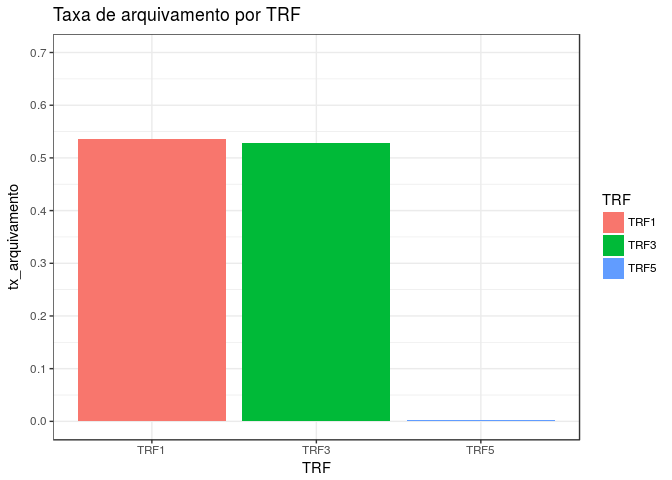

```r
tx_trfs <- dplyr::bind_rows(tx_trf1, tx_trf3, tx_trf5) %>% mutate(TRF = c("TRF1", "TRF3", "TRF5"))

ggplot(tx_trfs, aes(x = TRF, y = tx_arquivamento, fill = TRF))+ geom_col()+
  scale_y_continuous(breaks = seq(0,1,0.1))+expand_limits(y = .7)+theme_bw()+
  labs(title = "Taxa de arquivamento por TRF")
```

## TJ

### TJSP

```r
tjsp <- readr::read_rds("/home/nathang/Documentos/Scripts and Documents/ESTAGIO_ABJ/ABJ/tjs/consulta_processual/TJSP/data-raw_SP/data_rds/d_cposg.rds")
```

```r
glimpse(tjsp)
```

```
## Observations: 1,001
## Variables: 6
## $ id        <chr> "00000547820148260000", "00003021520128260000", "000...
## $ file      <chr> "/home/nathang/Documentos/Scripts and Documents/ESTA...
## $ hidden    <lgl> FALSE, FALSE, FALSE, FALSE, FALSE, FALSE, FALSE, FAL...
## $ data      <list> [<# A tibble: 12 x 2,    data              value   ...
## $ movs      <list> [<# A tibble: 53 x 2,    movement   description    ...
## $ decisions <list> [<# A tibble: 1 x 2,   date       decision         ...
```

```r
tjsp_2 <- tjsp %>%
  distinct(id, .keep_all = T)
```

1. Número de processos em segunda instância levantados.

```r
tjsp_2 %>% nrow()
```

```
## [1] 1001
```

2. Taxa de arquivamento nos processos de segunda instância

Para obter a taxa de arquivamento nos processos, basta procurar, por meio de `regex`, palavras que podem estar relacionadas com tal ação. As palavras escolhidas e suas variações foram, *rejeitar*, *declarar extinta* e *arquivou*

```r
tjsp_3 <- tjsp_2 %>% select(id, decisions) %>% tidyr::unnest()

tx_tjsp <- tjsp_3 %>%
  mutate(decision = str_to_lower(decision),
         decision = abjutils::rm_accent(decision),
         decision = str_replace_all(decision, "[[:punct:]]", " "),
         declar_dummy = case_when(str_detect(decision, "(declar[(amos)|(ou)])")~1,
                                        T~0),
         extinta_dummy = case_when(str_detect(decision, "(extinta)")~1,
                                        T~0),
         arquivamento_dummy = case_when(declar_dummy == 1 & extinta_dummy == 1| str_detect(decision, "(rejeit)|(arquiv)") ~1,
                                        T~0)) %>%
  summarise(tx_arquivamento = mean(arquivamento_dummy))

tx_tjsp
```

```
## # A tibble: 1 x 1
##   tx_arquivamento
##             <dbl>
## 1           0.762
```

## TJAL

```r
tjal <- readr::read_rds("/home/nathang/Documentos/Scripts and Documents/ESTAGIO_ABJ/ABJ/tjs/consulta_processual/TJAL/data-raw_AL/cposg_rds_AL/cposg.rds")
```

```r
glimpse(tjal)
```

```
## Observations: 8
## Variables: 5
## $ value          <chr> "/home/nathang/Documentos/Scripts and Documents...
## $ dados_processo <list> [<Criminal, Improbidade Administrativa, Ação P...
## $ partes         <list> [<Ministério Público, Carlos Alberto Moreira d...
## $ movimentacao   <list> [<# A tibble: 219 x 2,    data       movimento...
## $ julgamento     <list> [<12/05/2015, Julgado, à unanimidade de votos,...
```

1. Número de processos em segunda instância levantados.

```r
tjal %>% nrow()
```

```
## [1] 8
```

2. Taxa de arquivamento nos processos de segunda instância

Para obter a taxa de arquivamento nos processos, basta procurar, por meio de `regex`, palavras que podem estar relacionadas com tal ação. As palavras escolhidas e suas variações foram, *rejeitar*, *declarar extinta* e *arquivou*

```r
tjal <- tjal %>% select(value, julgamento) %>% tidyr::unnest()

tx_tjal <- tjal %>%
  mutate(decisao = str_to_lower(decisao),
         decisao = abjutils::rm_accent(decisao),
         decisao = str_replace_all(decisao, "[[:punct:]]", " "),
         declar_dummy = case_when(str_detect(decisao, "(declar[(amos)|(ou)])")~1,
                                        T~0),
         extinta_dummy = case_when(str_detect(decisao, "(extinta)")~1,
                                        T~0),
         arquivamento_dummy = case_when(declar_dummy == 1 & extinta_dummy == 1| str_detect(decisao, "(rejeit)|(arquiv)") ~1,
                                        T~0)) %>%
  summarise(tx_arquivamento = mean(arquivamento_dummy))

tx_tjal
```

```
## # A tibble: 1 x 1
##   tx_arquivamento
##             <dbl>
## 1           0.375
```

## TJDFT

```r
tjdft <- readr::read_rds("/home/nathang/Documentos/Scripts and Documents/ESTAGIO_ABJ/ABJ/tjs/jurisprudencia/TJDFT/data-raw/rds_files/data.rds")
```

1. Número de processos em segunda instância levantados.

```r
tjdft %>% nrow()
```

```
## [1] 80
```

2. Taxa de arquivamento nos processos de segunda instância

Para obter a taxa de arquivamento nos processos, basta procurar, por meio de `regex`, palavras que podem estar relacionadas com tal ação. As palavras escolhidas e suas variações foram, *rejeitar*, *declarar extinta* e *arquivou*

```r
tx_tjdft <- tjdft %>%
  mutate(decisao = str_to_lower(decisao),
         decisao = abjutils::rm_accent(decisao),
         decisao = str_replace_all(decisao, "[[:punct:]]", " "),
         declar_dummy = case_when(str_detect(decisao, "(declar[(amos)|(ou)])")~1,
                                        T~0),
         extinta_dummy = case_when(str_detect(decisao, "(extinta)")~1,
                                        T~0),
         arquivamento_dummy = case_when(declar_dummy == 1 & extinta_dummy == 1| str_detect(decisao, "(rejeit)|(arquiv)") ~1,
                                        T~0)) %>%
  summarise(tx_arquivamento = mean(arquivamento_dummy))

tx_tjdft
```

```
## # A tibble: 1 x 1
##   tx_arquivamento
##             <dbl>
## 1           0.450
```

## Visualização gráfica

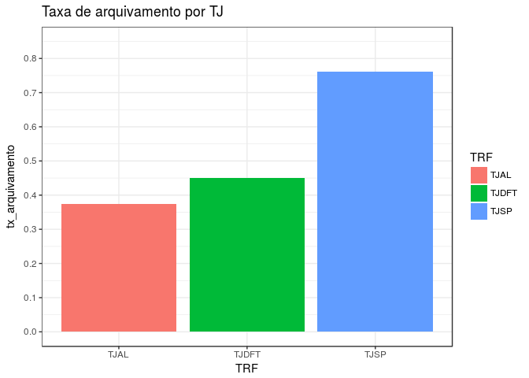

```r
tx_tj <- dplyr::bind_rows(tx_tjsp, tx_tjal, tx_tjdft) %>% mutate(TRF = c("TJSP", "TJAL", "TJDFT"))

ggplot(tx_tj, aes(x = TRF, y = tx_arquivamento, fill = TRF))+ geom_col()+
  scale_y_continuous(breaks = seq(0,1,0.1))+expand_limits(y = .85)+theme_bw()+
  labs(title = "Taxa de arquivamento por TJ")
```